# Analysing the relationship between the fuel consumption and the type of transmission

By jordiac, January 2017

Course Project of the Linear Regression course of the Data Scientist Specialization provided by Johns Hopkins University

# 1 Summary

The following report presents the results obtained by the linear regression of the *mtcars* data set from R library. This data set was extracted from the 1974 Motor Trend US magazine, and comprises fuel consumption and 10 aspects of automobile design and performance for 32 automobiles (1973-74 models).

The main objective is to analyze the impact of the automatic/manual transmission on the consumption in Miles per Gallon. Therefore this document will answer the following questions:

- **1**:Is an automatic or manual transmission better for MPG?
- **2**:Quantify the MPG difference between automatic and manual transmissions

# 2 Exploratory Data Analysis

Let’s have a quick look at the first 6 rows of the data set:

```
##                    mpg cyl disp  hp drat    wt  qsec vs am gear carb
## Mazda RX4         21.0   6  160 110 3.90 2.620 16.46  0  1    4    4
## Mazda RX4 Wag     21.0   6  160 110 3.90 2.875 17.02  0  1    4    4
## Datsun 710        22.8   4  108  93 3.85 2.320 18.61  1  1    4    1
## Hornet 4 Drive    21.4   6  258 110 3.08 3.215 19.44  1  0    3    1
## Hornet Sportabout 18.7   8  360 175 3.15 3.440 17.02  0  0    3    2
## Valiant           18.1   6  225 105 2.76 3.460 20.22  1  0    3    1
```

The following shows the Boxplot of the fuel consumption (in miles per gallon *mpg*) depending on whether the transmission is manual or automatic.

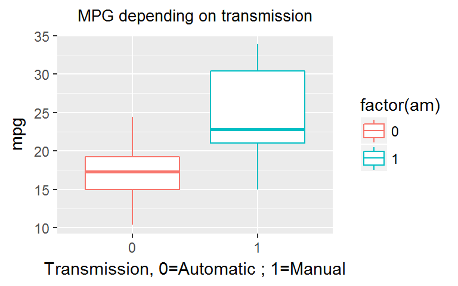

# 3 Linear Regression Analysis

## 3.1 Univariable Linear Regression

Let’s first perform a linear regression analysis using the **mpg** variable (fuel consumption in miles per gallon) as the outcome and the **am** variable (transmission: manual=1 vs automatic=0) as the regressor. We’ll consider the regressor as a factor variable.

```r
fit1 <- lm(mpg ~ factor(am), mtcars)
summary(fit1)$coef
```

```
##              Estimate Std. Error   t value     Pr(>|t|)
## (Intercept) 17.147368   1.124603 15.247492 1.133983e-15
## factor(am)1  7.244939   1.764422  4.106127 2.850207e-04
```

As it can be observed, the **p-value** for both automatic and manual transmissions is less than 0.05 so H0 hypothesis is rejected , and both seems to be **necessary regressors**.

However when we look at the R^2 value (**R^2=0.36**) we realize that only 36% of the variability of the model can be explained by the linear regression so we need to **consider more regressors** to make a good prediction.

When observing the lower and upper bounds for the **95% confidence interval** of the **automatic** transmission consumption: **(14.851, 19.444)** and the one for **manual**: **(18.493, 30.292)** we see that the upper bound for Automatic(0) transm. is almost identical than the lower bound for Manual(1). So again automatic consumption **tends** to be inferior than the manual one.

## 3.2 Multivariable Linear Regression

### 3.2.1 Nested models testing

We are going to compare some multivariable regression models using other variables in order to choose a more appropriate model to answer the main questions using the **ANOVA** test.

```r
mod1 <- lm( mpg ~ factor(am)+ cyl + wt, mtcars)
mod2 <- lm(mpg ~  factor(am) + cyl + hp + wt , mtcars )
mod3 <- lm(mpg ~ factor(am) + cyl + hp + wt  + disp + carb, mtcars )

test <- anova(fit1, mod1 , mod2, mod3)
```

```
## Analysis of Variance Table
##
## Model 1: mpg ~ factor(am)
## Model 2: mpg ~ factor(am) + cyl + wt
## Model 3: mpg ~ factor(am) + cyl + hp + wt
## Model 4: mpg ~ factor(am) + cyl + hp + wt + disp + carb
##   Res.Df    RSS Df Sum of Sq       F    Pr(>F)
## 1     30 720.90
## 2     28 191.05  2    529.85 41.0256 1.272e-08 ***
## 3     27 170.00  1     21.05  3.2596   0.08306 .
## 4     25 161.44  2      8.56  0.6627   0.52426
## ---
## Signif. codes:  0 '***' 0.001 '**' 0.01 '*' 0.05 '.' 0.1 ' ' 1
```

### 3.2.2 Checking Normality

We now check the normality of models *mod1* and *mod2* residuals using the **shapiro test** function from R:

```r
test_mod1 <- shapiro.test(mod1$residuals)
test_mod2 <- shapiro.test(mod2$residuals)
```

For *mod1* we obtain a p-value equals to **0.061** and for *mod2* the p-value is equal to **0.077** so both are **>0.05** so we **fail to reject normality** and we can be confident with the P-values from the F-test results shown in ANOVA test.

### 3.2.3 Comparing the main coefficients

Let’s compare the main coefficients from *mod1* & *mod2* regression models.

- **R^2 values:** For *mod1* we see that **83%** of the total variability is explained by the regression model and for *mod2* **R^2=84.9%**. Thus both models explain approximately the same % of *mpg* variation.
- **Variance inflation** We now analyze the variation inflation of *mod1* & *mod2* using the **car** library:

```r
vif(mod1)
```

```
## factor(am)        cyl         wt
##   1.924955   2.584066   3.609011
```

```r
vif(mod2)
```

```
## factor(am)        cyl         hp         wt
##   2.546159   5.333685   4.310029   3.988305
```

As expected *mod1* will lead to less variability than *mod2* and will avoid the increasing of the variance by NOT including unnecessary variables.

- **Slope and intercept coefficients**

-For *mod2* :

```r
summary(mod2)$coef
```

```
##                Estimate Std. Error   t value     Pr(>|t|)
## (Intercept) 36.14653575 3.10478079 11.642218 4.944804e-12
## factor(am)1  1.47804771 1.44114927  1.025603 3.141799e-01
## cyl         -0.74515702 0.58278741 -1.278609 2.119166e-01
## hp          -0.02495106 0.01364614 -1.828433 7.855337e-02
## wt          -2.60648071 0.91983749 -2.833632 8.603218e-03
```

We decide to select *mod2* even if it has more variance inflation.

# 4 Conclusions

After analyzing the data set using linear regression, we can conclude that:

-As per **$3.1** of this report, the **T.TEST** inference results show that the *mpg* consumption for cars with **Automatic** and **Manual** transmission is **significatively different**.

-Having **Manual** transmission leads to **1.48** more miles per gallon consumption than **Automatic** transmission. (1.48 adjusted for hp, cyl, and wt).

-Miles per gallon consumption will **decrease** by **2.60** for each 1000lb increase of the car weight.

# 5 Appendix 1: Residuals and Diagnostics

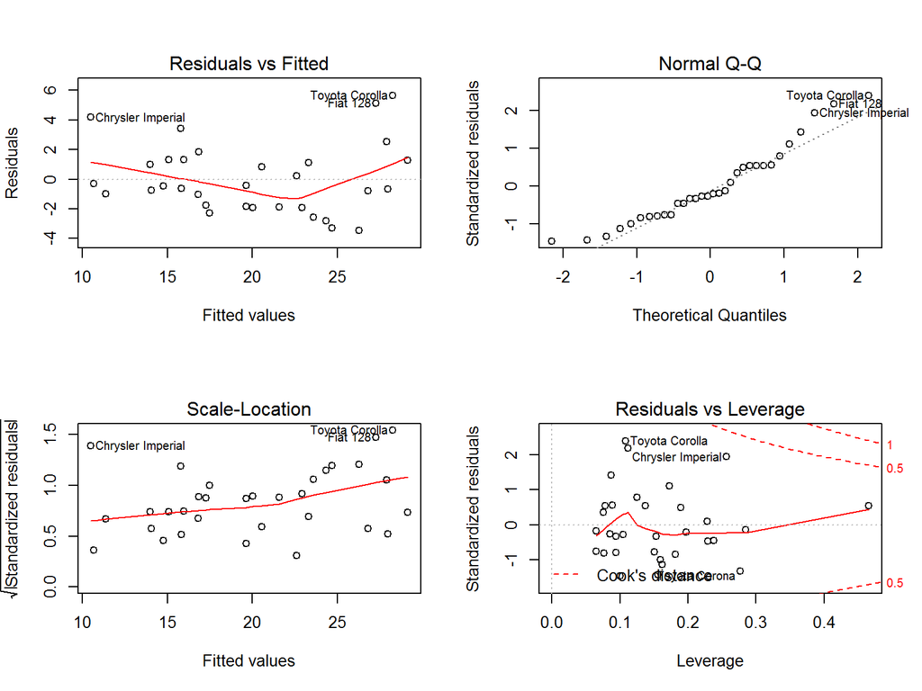

```r
par(mfrow=c(2, 2))
plot(mod2)
```

-The **Normal Q-Q** plot indicates that residuals are **Normally** distributed because they fall on the line.

-Concerning **Residuals vs Leverage** plot, we notice that there might be an **outlier** (see right point)